# Quantitative ethnobotany analysis with ethnobotanyR

Cory Whitney

2019-02-13

# ethnobotanyR

[figure not shown]

The `ethnobotanyR` package can be used to calculate common quantitative ethnobotany indices to assess the cultural significance of plant species based on informant consensus. The package closely follows two papers, one by Tardio and Pardo-de-Santayana (2008) and another by Whitney et al. (2018).

An example data set called `ethnobotanydata` is provided to show what the layout for standard ethnobotany data should be like to interface with the `ethnobotanyR` package. This is an ethnobotany data set including one column of 20 knowledge holder identifiers `informant` and one of four species names `sp_name`. The rest of the columns are the identified ethnobotany use categories. The data in the use categories is populated with counts of uses per person (should be 0 or 1 values). [^1]

First six rows of the example ethnobotany data included with ethnobotanyR

| informant | sp_name | Use_1 | Use_2 | Use_3 | Use_4 | Use_5 | Use_6 | Use_7 | Use_8 | Use_9 | Use_10 |
| --- | --- | --- | --- | --- | --- | --- | --- | --- | --- | --- | --- |
| inform_a | sp_a | 0 | 0 | 1 | 0 | 0 | 0 | 0 | 1 | 1 | 0 |
| inform_a | sp_b | 0 | 0 | 0 | 0 | 0 | 0 | 0 | 0 | 0 | 0 |
| inform_a | sp_c | 0 | 0 | 0 | 0 | 0 | 1 | 1 | 0 | 0 | 0 |
| inform_a | sp_d | 0 | 0 | 0 | 0 | 0 | 0 | 0 | 0 | 0 | 0 |
| inform_b | sp_a | 0 | 1 | 1 | 0 | 0 | 1 | 0 | 0 | 1 | 0 |
| inform_b | sp_b | 1 | 0 | 0 | 0 | 0 | 0 | 1 | 0 | 0 | 0 |

## `ethnobotanyR` package functions

The use report `URs()` function calculates the use report (UR) for each species in the data set.
$$\begin{equation}
UR_{s} = \sum_{u=u_1}^{^uNC} \sum_{i=i_1}^{^iN} UR_{ui}
\end{equation}$$

`URs()` calculates the total uses for the species by all informants (from $i_1$ to $^iN$) within each use-category for that species $(s)$. It is a count of the number of informants who mention each use-category $NC$ for the species and the sum of all uses in each use-category (from $u_1$ to $^uNC$).

```r
ethnobotanyR::URs(ethnobotanydata)
```

```
#>   sp_name URs
#> 1    sp_c  52
#> 2    sp_a  43
#> 3    sp_d  43
#> 4    sp_b  36
```

`Radial_plot()` shows these results together with a radial plot for quick assessment of the result using the `ggplot2` library.

```
#>   sp_name URs
#> 1    sp_c  52
#> 2    sp_a  43
#> 3    sp_d  43
#> 4    sp_b  36
```

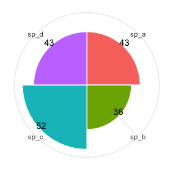

```r
ethnobotanyR::Radial_plot(ethnobotanydata, ethnobotanyR::URs)
```

The `URsum()` function calculates the sum of all ethnobotany use reports (UR) for all species in the data set.

```r
ethnobotanyR::URsum(ethnobotanydata)
```

```
#> [1] "Sum of all Use Reports (UR) for all species in the data set"
#> [1] 174
```

The `CIs()` function is run with calculates the Cultural Importance Index (CI) for each species in the data set.
$$\begin{equation}
CI_{s} = \sum_{u=u_1}^{^uNC} \sum_{i=i_1}^{^iN} UR_{ui/N}.
\end{equation}$$

```
#>   sp_name     CI
#> 1    sp_c 0.2364
#> 2    sp_a 0.1955
#> 3    sp_d 0.1955
#> 4    sp_b 0.1636
```

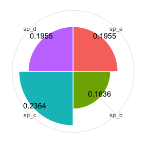

```r
ethnobotanyR::Radial_plot(ethnobotanydata, ethnobotanyR::CIs)
```

The `FCs()` function calculates the frequency of citation (FC) for each species in the data set.
$$\begin{equation}
FC_s = \sum_{i=i_1}^{^iN} UR_i
\end{equation}$$

`FCs()` is the sum of informants that cite a use for the species.

```
#>   sp_name FCs
#> 1    sp_c  17
#> 2    sp_a  15
#> 3    sp_b  12
#> 4    sp_d  12
```

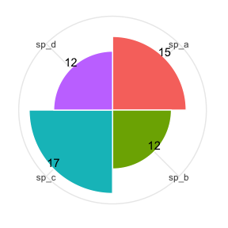

```r
ethnobotanyR::Radial_plot(ethnobotanydata, ethnobotanyR::FCs)
```

The `NUs()` function calculates the number of uses (NU) for each species in the data set.
$$\begin{equation}
NU_s = \sum_{u=u_1}^{^uNC}
\end{equation}$$

$NC$ are the number of use categories. `NUs()` is the sum of all categories for which a species is considered useful.

```
#>   sp_name NUs
#> 1    sp_c   8
#> 2    sp_d   8
#> 3    sp_a   7
#> 4    sp_b   7
```

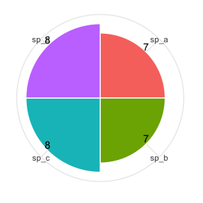

```r
ethnobotanyR::Radial_plot(ethnobotanydata, ethnobotanyR::NUs)
```

The `RFCs()` function calculates the relative frequency of citation (RFC) for each species in the data set.
$$\begin{equation}
RFC_s = \frac{FC_s}{N} = \frac{\sum_{i=i_1}^{^iN} UR_i}{N}
\end{equation}$$

$FC_s$ is the frequency of citation for each species $s$, $UR_i$ are the use reports for all informants $i$ and $N$ is the total number of informants interviewed in the survey.

```
#>   sp_name RFCs
#> 1    sp_c 0.85
#> 2    sp_a 0.75
#> 3    sp_b 0.60
#> 4    sp_d 0.60
```

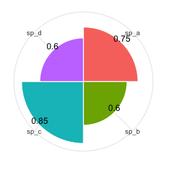

```r
ethnobotanyR::Radial_plot(ethnobotanydata, ethnobotanyR::RFCs)
```

The `RIs()` function calculates the relative importance index (RI) for each species in the data set.
$$\begin{equation}
RI_s = \frac{RFC_{s(max)} + RNU_{s(max)}}{2}
\end{equation}$$

$RFC_{s(max)}$ is the relative frequency of citation for the species $s$ over the maximum, $RNU_{s(max)}$ is the relative number of uses for $s$ over the maximum.

```
#>   sp_name   RIs
#> 1    sp_c 0.925
#> 2    sp_a 0.812
#> 3    sp_d 0.800
#> 4    sp_b 0.738
```

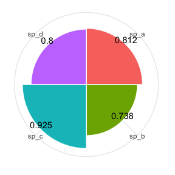

```r
ethnobotanyR::Radial_plot(ethnobotanydata, ethnobotanyR::RIs)
```

The `UVs()` function calculates the use value (UV) index for each species in the data set.
$$\begin{equation}
UV_{s} = \sum U_i/N
\end{equation}$$

$U_i$ is the number of different uses mentioned by each informant $i$ and $N$ is the total number of informants interviewed in the survey.

```
#>   sp_name  UVs
#> 1    sp_c 2.60
#> 2    sp_a 2.15
#> 3    sp_d 2.15
#> 4    sp_b 1.80
```

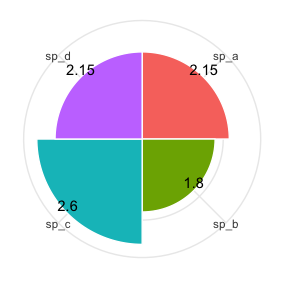

```r
ethnobotanyR::Radial_plot(ethnobotanydata, ethnobotanyR::UVs)
```

The `FLs()` function calculates the fidelity level (FL) per species in the study. It is a way of calculating the percentage of informants who use a plant for the same purpose as compared to all uses of all plants.

$$\begin{equation}
FL_{s} = \frac {N_{s}}{UR_{s}}
\end{equation}$$

```r
ethnobotanyR::FLs(ethnobotanydata)
```

```
#>    sp_name variable       FLs
#> 1     sp_c    Use_8 23.076923
#> 2     sp_a    Use_3 20.930233
#> 3     sp_d    Use_8 20.930233
#> 4     sp_b    Use_7 19.444444
#> 5     sp_a    Use_2 18.604651
#> 6     sp_d    Use_7 18.604651
#> 7     sp_c    Use_1 17.307692
#> 8     sp_b    Use_1 16.666667
#> 9     sp_a    Use_6 16.279070
#> 10    sp_d    Use_3 16.279070
#> 11    sp_a    Use_8 13.953488
#> 12    sp_b    Use_3 13.888889
#> 13    sp_b    Use_6 13.888889
#> 14    sp_b    Use_9 13.888889
```

[output cut: 16 more lines]

## `ethnobotanyR` chord diagrams with `circlize`

The following chord plots are made using functions from the `circlize` package. An example of the application of chord plots in ethnobotany is described by Whitney et al. (2018).

The `ethnoChord()` function creates a chord diagram of ethnobotany uses and species.

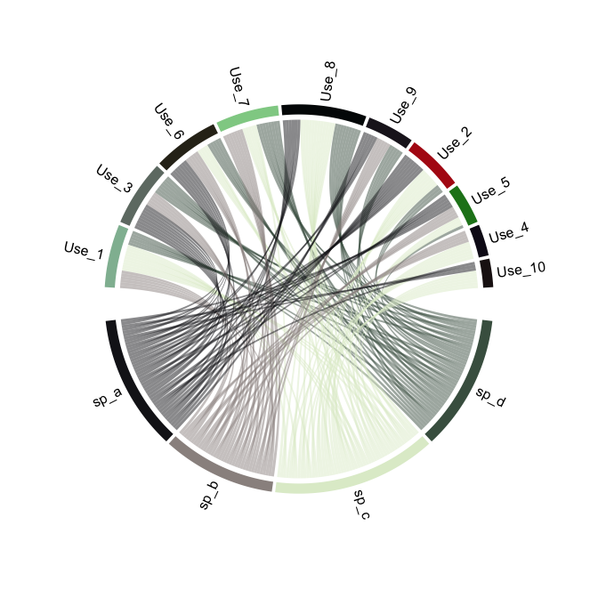

```
#> [1] "Chord diagram for each use related to each species in the data set"
```

```r
ethnobotanyR::ethnoChord(ethnobotanydata)
```

The `ethnoChordUser()` function creates a chord diagram of informants and species uses for ethnobotany studies.

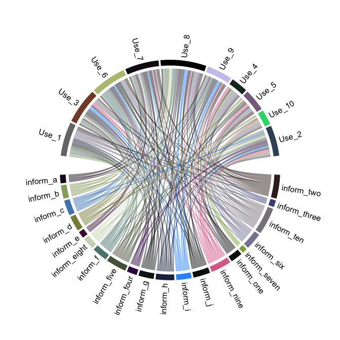

```
#> [1] "Chord diagram for each use related to each informant in the data set"
```

```r
ethnobotanyR::ethnoChordUser(ethnobotanydata)
```

## References

Tardio, J., and M. Pardo-de-Santayana, 2008. Cultural Importance Indices: A Comparative Analysis Based on the Useful Wild Plants of Southern Cantabria (Northern Spain) 1. Economic Botany, 62(1), 24-39. https://doi.org/10.1007/s12231-007-9004-5.

Whitney, C. W., Bahati, J., and Gebauer, J. (2018), Ethnobotany and agrobiodiversity; valuation of plants in the homegardens of southwestern Uganda. Ethnobiology Letters, 9(2), 90-100. https://doi.org/10.14237/ebl.9.2.2018.503

[^1]: The example `ethnobotanydata` is included with the `ethnobotanyR` package but can also be downloaded from GitHub https://github.com/CWWhitney/ethnobotanyR/tree/master/data.